# Snow

## `xarray`

**By**: *Victor Cornejo*

## Introduction

In this project I explored worldwide snow levels using the `xarray` package, uncovering interesting trends in snow density over time.

```python
import pandas as pd
import numpy as np
import matplotlib.pyplot as plt
import plotly.express as px
import seaborn as sns
import xarray as xr
from pathlib import Path

plt.style.use('fivethirtyeight') # Use plt.style.available to see more styles
sns.set()
sns.set_context("talk")
np.set_printoptions(threshold=5) # avoid printing out big matrices
%matplotlib inline
```

# ERA5 Snow Cover

In this part of the task, I explored worldwide snow accumulation trends from the ERA5 dataset. More specifically, I wanted to look at the yearly minimum and maximum snow accumulation levels, and see if there were any interesting trends. I used `xarray` to accomplish this part.

```python
DATA_DIR = Path('./data')
monthly_2deg_path = DATA_DIR / "era5_snow_monthly_2deg_aws_v20210920.nc"
ds = xr.open_dataset(monthly_2deg_path)
```

First, I looked at the output of the `xarray.Dataset` object

```python
ds
```

```
<xarray.Dataset>
Dimensions:       (time: 504, latitude: 90, longitude: 180)
Coordinates:
  * time          (time) datetime64[ns] 1979-01-16T11:30:00 ... 2020-12-16T11...
  * latitude      (latitude) float32 -88.88 -86.88 -84.88 ... 85.12 87.12 89.12
  * longitude     (longitude) float32 0.875 2.875 4.875 ... 354.9 356.9 358.9
Data variables:
    snow_density  (time, latitude, longitude) float32 ...
```

In the variable `ds`, I had an `xarray.Dataset` object with one `xarray.DataArray` object, consisting of `snow_density` measurements across time and location. Next, I extracted the `xarray.DataArray` object consisting of snow density measurements, similar to extracting a column from a `Pandas.DataFrame`.

```python
snow = ds.snow_density
snow
```

```
<xarray.DataArray 'snow_density' (time: 504, latitude: 90, longitude: 180)>
[8164800 values with dtype=float32]
Coordinates:
  * time       (time) datetime64[ns] 1979-01-16T11:30:00 ... 2020-12-16T11:30:00
  * latitude   (latitude) float32 -88.88 -86.88 -84.88 ... 85.12 87.12 89.12
  * longitude  (longitude) float32 0.875 2.875 4.875 6.875 ... 354.9 356.9 358.9
Attributes:
    long_name:       Snow density
    nameCDM:         Snow_density_surface
    nameECMWF:       Snow density
    product_type:    analysis
    shortNameECMWF:  rsn
    standard_name:   snow_density
    units:           kg m**-3
```

With `xarray` is also nice in that, if I wanted to average the snow density measurements across all time and plot the aggregate values by spatial location, I could do this in two lines of code.

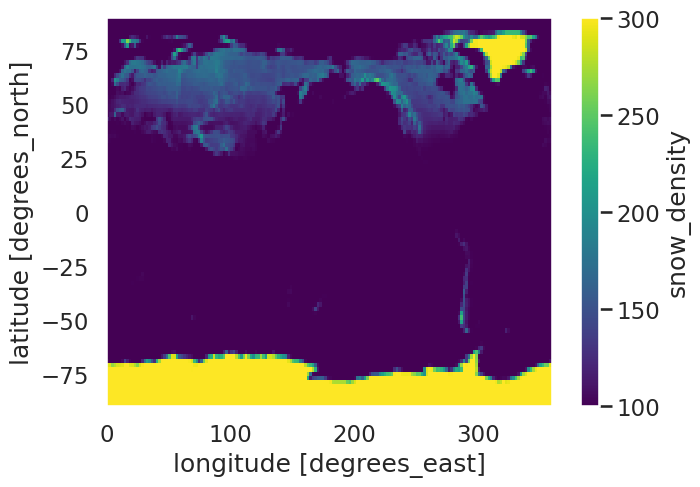

```python
# run this cell
mean_map = ds.mean("time")  # takes the mean across all variables in ds
mean_map.snow_density.plot(); # extract snow_density DataArray, then plot
```

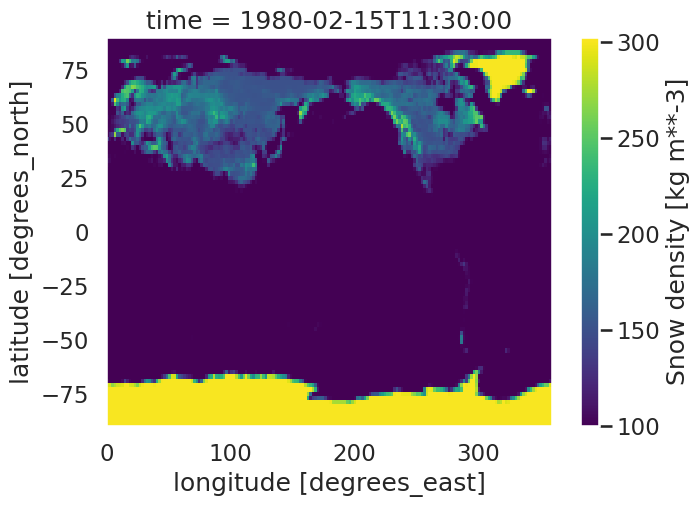

```python
snow.sel(time='1980-02').plot();
```

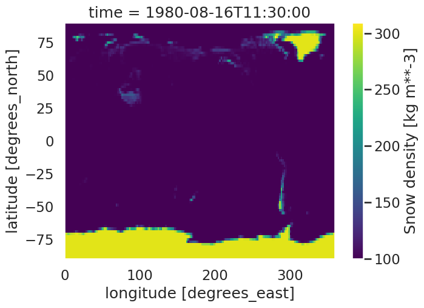

```python
snow.sel(time='1980-08').plot();
```

I could notice how these plots made a lot of sense: snow cover is higher in the Northern hemisphere during winter time, and when summer comes around, that snow melts. However, at the same time, winter arrives in the Southern hemisphere, and so snow appears on mountains in South America and New Zealand.

I then continued analyzing the data, with the ultimate goal of understanding and displaying trends of snow accumulation over the years using `xarray`.

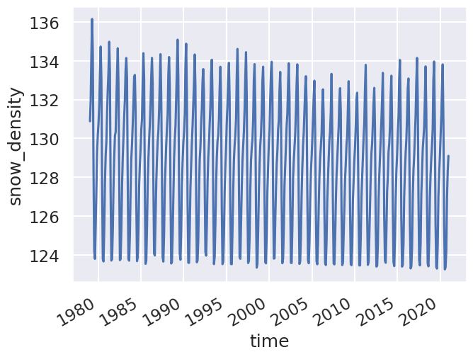

```python
t_snow_north = snow.sel(latitude=slice(-90,90)).mean(dim=['latitude', 'longitude'])
t_snow_north.plot();
```

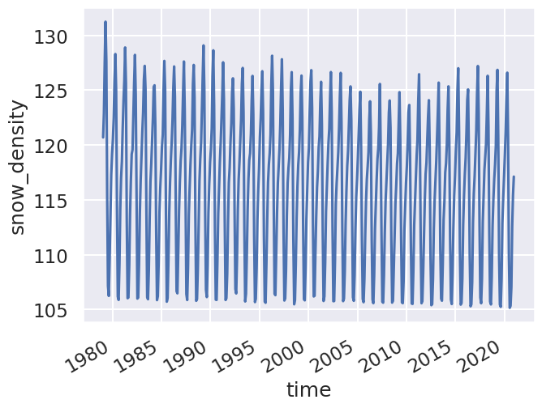

```python
t_snow_south = snow.sel(latitude=slice(0,90)).mean(dim=['latitude', 'longitude'])
t_snow_south.plot();
```

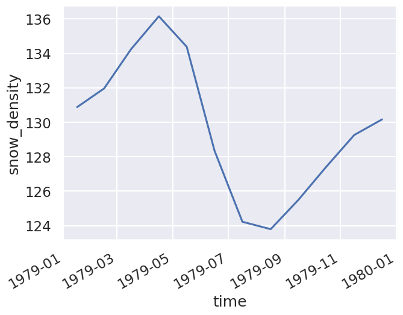

```python
t_snow_north.sel(time='1979').plot();
```

For this part, I filled in the `extract_peaks` function such that, if I plugged in an `xarray.DataArray` containing average snow density measurements for each hemisphere over time, I'd return a `pandas.DataFrame`.

When constructing the `extract_peaks` function, I thought about what information I wanted my DataFrame to contain, what information my `xarray.DataArray` objects contained already, and how I could write code to get the desired output.

So:

```python
t_snow_north.sel(time='1979')
```

```
<xarray.DataArray 'snow_density' (time: 12)>
array([130.88194, 131.96179, 134.23943, ..., 127.42577, 129.2612 ,
       130.16638], dtype=float32)
Coordinates:
  * time     (time) datetime64[ns] 1979-01-16T11:30:00 ... 1979-12-16T11:30:00
```

```python
t_snow_north.time.dt.year.values
```

```
array([1979, 1979, 1979, ..., 2020, 2020, 2020])
```

```python
t_snow_north.sel(time=str(1979)).min()
```

```
<xarray.DataArray 'snow_density' ()>
array(123.7948, dtype=float32)
```

```python
t_snow_north.sel(time='1979').idxmin().values.item()
```

```
303651000000000000
```

```python
min_day = t_snow_north.sel(time=str(1979)).idxmin().dt.dayofyear.values.item()
min_day
```

```
228
```

```python
t_snow_north.idxmin()
```

```
<xarray.DataArray 'time' ()>
array('2020-07-16T11:30:00.000000000', dtype='datetime64[ns]')
```

```python
def extract_peaks(snow_data):
    vals = []
    years = snow_data.time.dt.year.values
    peaks = []
    for year in set(years):
        min_date = snow_data.sel(time=str(year)).idxmin()
        max_date = snow_data.sel(time=str(year)).idxmax()
        min_dayofyear = snow_data.sel(time=str(year)).idxmin().dt.dayofyear.values.item()
        max_dayofyear = snow_data.sel(time=str(year)).idxmax().dt.dayofyear.values.item()
        min_snow = snow_data.sel(time=str(year)).min().values.item()
        max_snow = snow_data.sel(time=str(year)).max().values.item()
        amplitude = max_snow - min_snow
        vals = [year, min_date, max_date, min_dayofyear, max_dayofyear, min_snow, max_snow, amplitude]
        peaks.append(vals)

    snow_peaks = pd.DataFrame(peaks,
                              columns = ['year', 'min_date', 'max_date',
                                         'min_dayofyear', 'max_dayofyear',
                                         'min_snow', 'max_snow', 'amplitude'])

    return snow_peaks

peaks_north = extract_peaks(t_snow_north)
peaks_north.head()
```

|  | year | min_date | max_date | min_dayofyear | max_dayofyear | min_snow | max_snow | amplitude |
| --- | --- | --- | --- | --- | --- | --- | --- | --- |
| 0 | 1979 | <xarray.DataArray 'time' ()>\narray('1979-08-1... | <xarray.DataArray 'time' ()>\narray('1979-04-1... | 228 | 105 | 123.794800 | 136.151566 | 12.356766 |
| 1 | 1980 | <xarray.DataArray 'time' ()>\narray('1980-08-1... | <xarray.DataArray 'time' ()>\narray('1980-04-1... | 229 | 106 | 123.659767 | 134.730194 | 11.070427 |
| 2 | 1981 | <xarray.DataArray 'time' ()>\narray('1981-07-1... | <xarray.DataArray 'time' ()>\narray('1981-04-1... | 197 | 105 | 123.708542 | 134.978912 | 11.270370 |
| 3 | 1982 | <xarray.DataArray 'time' ()>\narray('1982-07-1... | <xarray.DataArray 'time' ()>\narray('1982-04-1... | 197 | 105 | 123.734169 | 134.644180 | 10.910011 |
| 4 | 1983 | <xarray.DataArray 'time' ()>\narray('1983-08-1... | <xarray.DataArray 'time' ()>\narray('1983-04-1... | 228 | 105 | 123.703926 | 134.141586 | 10.437660 |

With this DataFrame, I could now quickly explore several questions. For example, during what day of the year do the min and max happen?

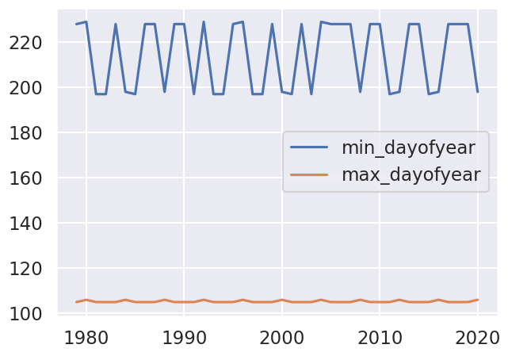

```python
# run this cell
plt.plot('year', 'min_dayofyear', data=peaks_north);
plt.plot('year', 'max_dayofyear', data=peaks_north);
plt.legend();
```

What was the min and max amount of snow at those times?

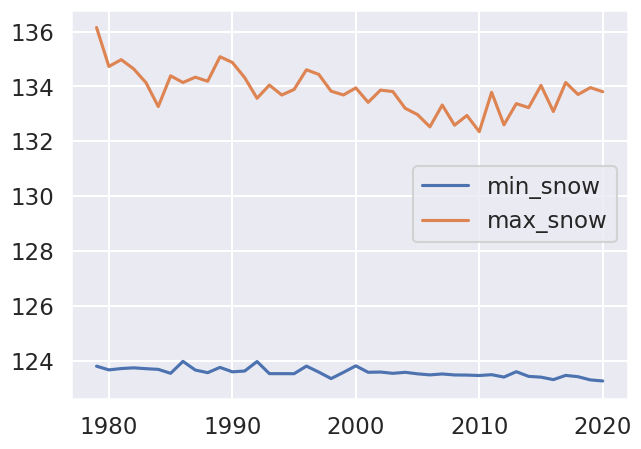

```python
plt.plot('year', 'min_snow', data=peaks_north);
plt.plot('year', 'max_snow', data=peaks_north);
plt.legend();
```

Given the difference in scales, it was a bit easier to see what was happening if I plotted the min and max separately:

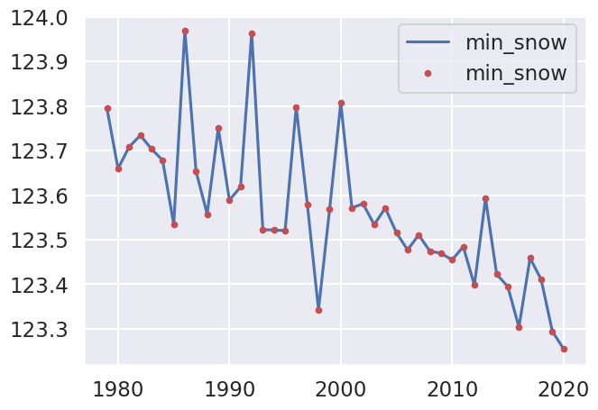

```python
plt.plot('year', 'min_snow', data=peaks_north);
plt.plot('year', 'min_snow', 'r.', data=peaks_north);
plt.legend();
```

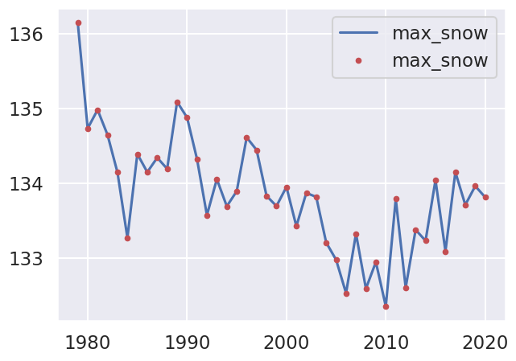

```python
plt.plot('year', 'max_snow', data=peaks_north);
plt.plot('year', 'max_snow', 'r.', data=peaks_north);
plt.legend();
```